# Analyzing activity monitoring devices data

Raj Kumar

11/15/2019

## Overview

This project is about analyzing data from a personal activity monitoring device.This device collects data at 5 minute intervals through out the day.  
The data consists of two months of data from an anonymous individual collected during the months of October and November, 2012 and include the number of steps taken in 5 minute intervals each day.

The data for this assignment can be downloaded from the course web site:  
*Dataset* : [Activity monitoring data](https://d396qusza40orc.cloudfront.net/repdata%2Fdata%2Factivity.zip)

The variables included in this dataset are:  
- *steps*: Number of steps taking in a 5-minute interval  
- *date*: The date on which the measurement was taken in YYYY-MM-DD format  
- *interval*: Identifier for the 5-minute interval in which measurement was taken

The dataset is stored in a comma-separated-value (CSV) file and there are a total of 17,568 observations in this dataset.

## Importing Libraries and working directory

```r
library(dplyr)
library(ggplot2)

##Setting working directory
setwd("C:\\Users\\Razzz\\Desktop\\Reproducible research assignment\\Data")
```

## Loading and preprocessing the data

```r
# 1) Importing Dataset and processing
raw_data <- read.csv('activity.csv')

#Basic EDA
summary(raw_data)
```

```
##      steps                date          interval
##  Min.   :  0.00   2012-10-01:  288   Min.   :   0.0
##  1st Qu.:  0.00   2012-10-02:  288   1st Qu.: 588.8
##  Median :  0.00   2012-10-03:  288   Median :1177.5
##  Mean   : 37.38   2012-10-04:  288   Mean   :1177.5
##  3rd Qu.: 12.00   2012-10-05:  288   3rd Qu.:1766.2
##  Max.   :806.00   2012-10-06:  288   Max.   :2355.0
##  NA's   :2304     (Other)   :15840
```

```r
head(raw_data)
```

```
##   steps       date interval
## 1    NA 2012-10-01        0
## 2    NA 2012-10-01        5
## 3    NA 2012-10-01       10
## 4    NA 2012-10-01       15
## 5    NA 2012-10-01       20
## 6    NA 2012-10-01       25
```

## Number of steps per day

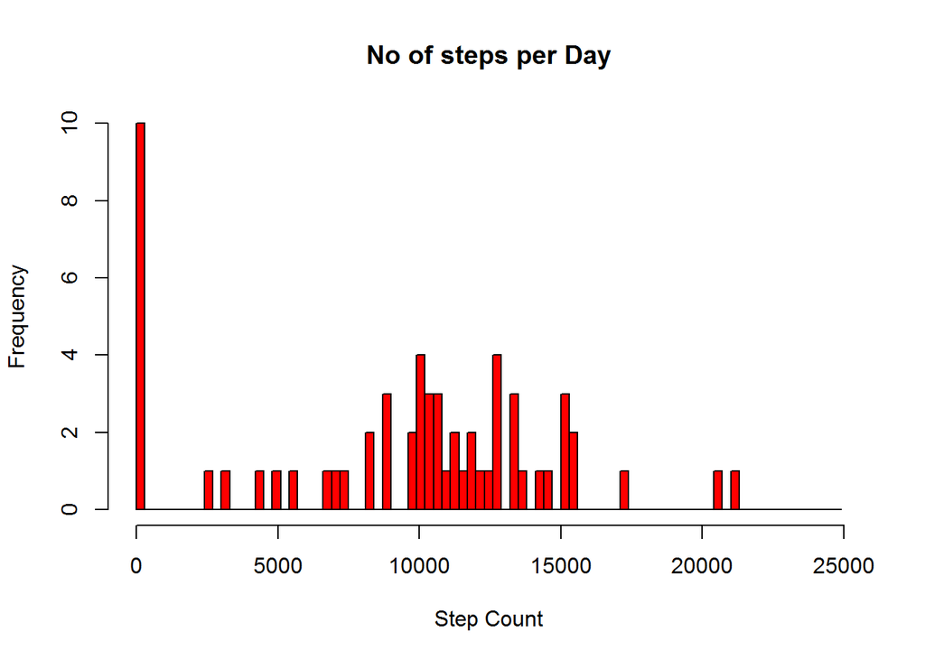

```r
## 2) Histogram of the total number of steps taken each day
daily_step <- raw_data %>%
              group_by(date) %>%
              summarise(Step_count = sum(steps,na.rm = TRUE))
#Histogram of the above data
hist(daily_step$Step_count,breaks=seq(0,25000,by= 300),main = "No of steps per Day",xlab = "Step Count",col = "red")
```

```r
## 3.a) Mean number of steps taken each day
#mean step per day
mean(daily_step$Step_count)
```

```
## [1] 9354.23
```

```r
## 3.b) Median number of steps taken each day
median(daily_step$Step_count)
```

```
## [1] 10395
```

## Average daily activity pattern

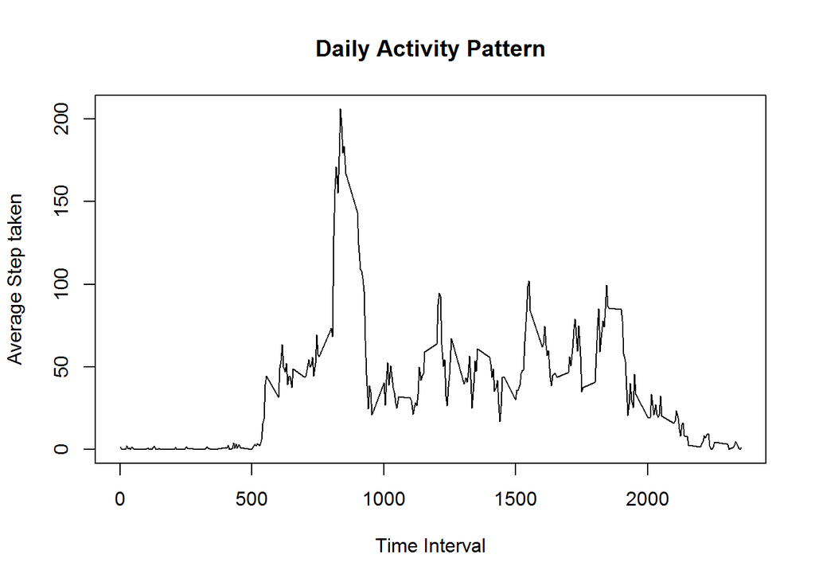

```r
#mean number of steps
daily_activity <- raw_data %>%
                  group_by(interval) %>%
                  summarise(average_steps = mean(steps,na.rm = TRUE))

## 4.)Time series plot of the average number of steps taken
plot(daily_activity$interval,daily_activity$average_steps,type = 'l',
     main = "Daily Activity Pattern",xlab = "Time Interval",ylab = "Average Step taken")
```

```r
## 5.) The 5-minute interval that, on average, contains the maximum number of steps
daily_activity[(which(daily_activity$average_steps == max(daily_activity$average_steps))),c("interval")]
```

```
## # A tibble: 1 x 1
##   interval
##      <int>
## 1      835
```

## Imputing Null values

```r
colSums(is.na(raw_data))
```

```
##    steps     date interval
##     2304        0        0
```

Steps columns have 2304 NAs value

### Strategy for imputing NULL values

Impute null values of steps with the mean number of steps taken in interval corresponding to null values

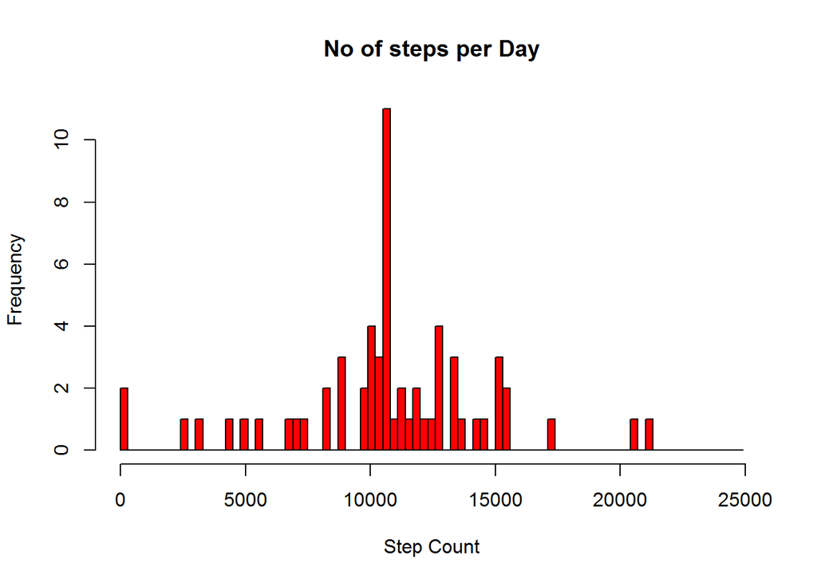

```r
# 6.) Code to describe and show a strategy for imputing missing data
processed_data <- left_join(raw_data,daily_activity,"interval"="interval")
processed_data$step_imputed <- ifelse(is.na(processed_data$steps),processed_data$average_steps,
                                      processed_data$steps)
processed_data <- processed_data[,c("step_imputed","date","interval")]
colnames(processed_data)= c("Steps","date","interval")

#daily activity pattern after processing data
daily_activity_processed <- processed_data %>%
                            group_by(date) %>%
                            summarise(avg_step_count = sum(Steps))

## 7.)Histogram of the total number of steps taken each day after missing values are imputed
hist(daily_activity_processed$avg_step_count,breaks=seq(0,25000,by= 300),main = "No of steps per Day",xlab = "Step Count",col = "red")
```

```r
##Mean and median values after imputing nulls
mean(daily_activity_processed$avg_step_count)
```

```
## [1] 10766.19
```

```r
median(daily_activity_processed$avg_step_count)
```

```
## [1] 10766.19
```

## Activity patterns between weekdays and weekends

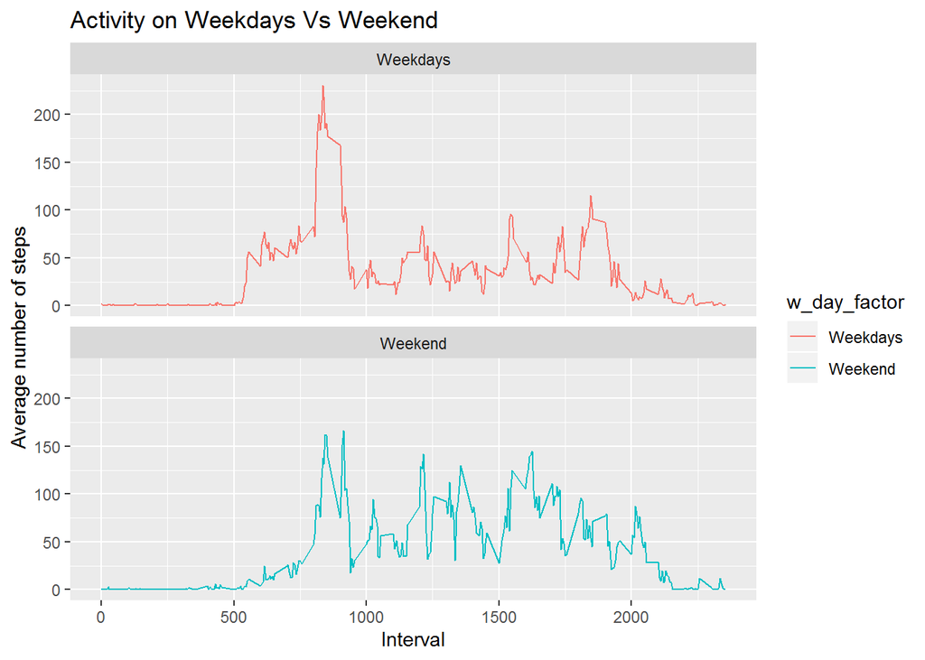

```r
wday_proc_data <- processed_data
wday_proc_data$date <- as.POSIXct(wday_proc_data$date, "%Y-%m-%d")

#Create a new factor variable in the dataset with two levels – “weekday” and “weekend”
wday_proc_data$w_day <- weekdays(wday_proc_data$date)
wday_proc_data$w_day_factor <- as.factor(ifelse(wday_proc_data$w_day == 'Saturday' | wday_proc_data$w_day == 'Sunday',"Weekend","Weekdays"))

#Calculating average daily steps
wday_proc_data_avg <- wday_proc_data %>%
                      group_by(interval,w_day_factor) %>%
                      summarise(avg_step_count = mean(Steps))


## 9.)Panel plot comparing the average number of steps taken per 5-minute interval across weekdays and weekends

timeseries_plot<- ggplot(wday_proc_data_avg, aes(x = interval , y = avg_step_count, color = w_day_factor)) +
  geom_line() +
  labs(title = "Activity on Weekdays Vs Weekend", x = "Interval", y = "Average number of steps") +
  facet_wrap(~w_day_factor, ncol = 1, nrow=2)
print(timeseries_plot)
```